# Lab Assignment 2

Nora Quick

## Questions:

### Q1.How consistent are these data with Mendel’s hypothesis of independence? Notice that in this particular case, we’re not interested in a *departure* from independence, but rather a *confirmation* of independence. Is a Chi-squared test appropriate here? Why or why not?

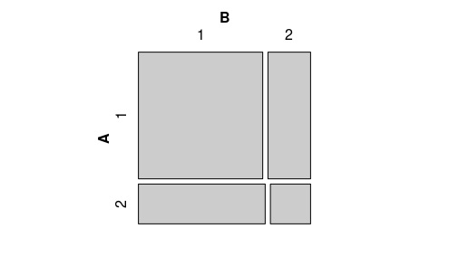

```r
tab1 <- matrix(c(315, 108, 101, 32),2,2,byrow=TRUE)
mosaic(tab1)
```

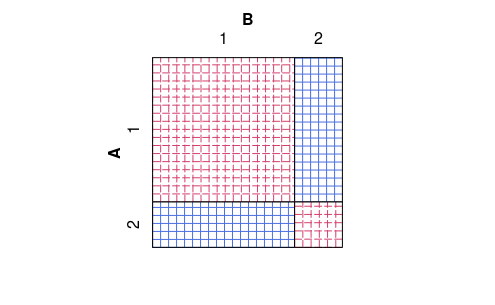

```r
sieve(tab1, shade = TRUE)
```

Based on the two graphs above I believe that the data is approximately independent.

Because the Chi-Squared test is used to test and no necessarily confirm independence (what we want to do here) I would say that it is not needed here.

### Q2.

```r
norm <- rnorm(1000)
chi <- rchisq(1000, df = 1)
```

```r
sqnorm <- norm * norm
```

```r
dnorm <- density(sqnorm)
dchi <- density(chi)
```

#### (a) Construct separate histograms/density plots of the raw chi-squared values and the *squares* of the standard normal values. What do you observe?

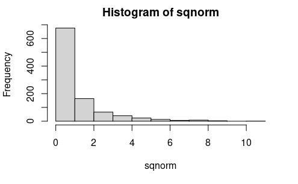

```r
hist(sqnorm)
```

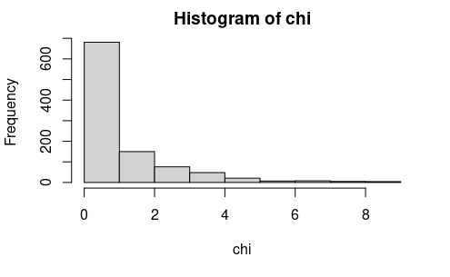

```r
hist(chi)
```

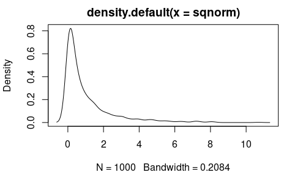

```r
plot(dnorm)
```

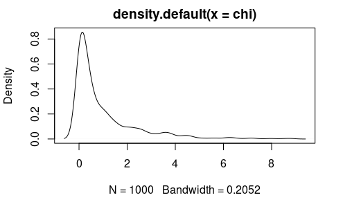

```r
plot(dchi)
```

I am very shocked to observe that in both cases of the histogram and the density are very similar.

#### (b) Recall (or obtain from `qnorm(0.975)` that the *2-sided 95%* critical values for the standard normal distribution are ± 1.96. Use `qchisq()` to compare the *square* of these 2-sided 95% critical values from the standard normal to the *one-sided* 95% critical value for the Chi-squared(1). What does this suggest about tests based on these two reference distributions?

```r
qnorm(0.975)
```

```
[1] 1.959964
```

```r
sqrt(qchisq(chi, df = 1))
```

```
NaNs produced
```

[output not shown]

[output cut: 485 more lines]